# re_ml_01

Jonathan Lanz 23-106-255

2025-05-19

## 1 Comparison of the linear regression and KNN models

In the first part of this report, I run through a linear regression model and a KNN model, evaluated on a training and a test set. The goal is to identify the differences and be able to interpret and understand them. For both parts of the report, I use a dataset that contains a time series of ecosystem gross primary production (GPP) from Davos with multiple other meteorological variables measured in parallel.

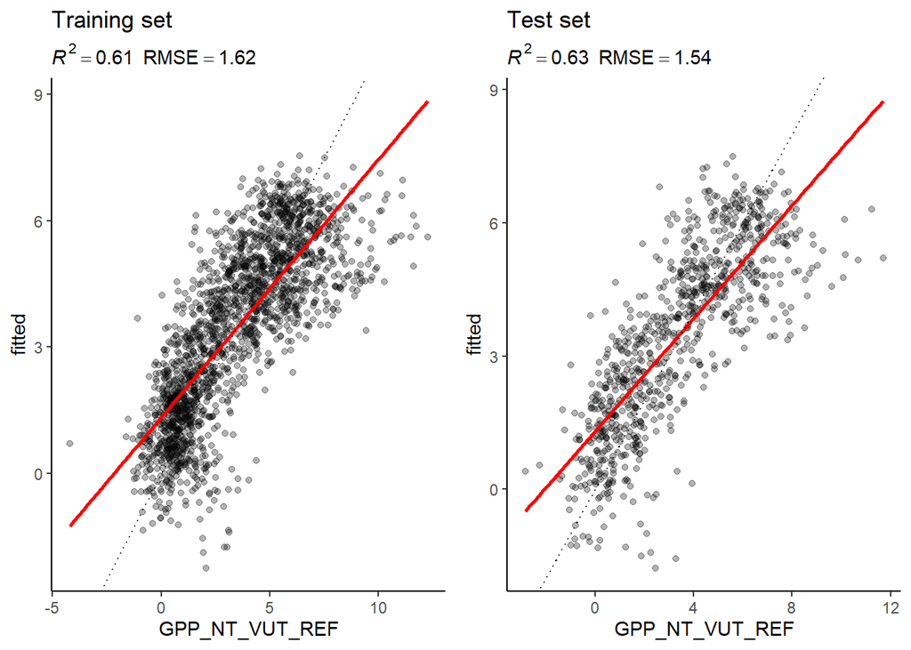

```r
knitr::opts_chunk$set(echo = TRUE)

library(dplyr)
library(ggplot2)
library(readr)
library(tidyr)
library(caret)
library(recipes)
library(here)
library(cowplot)
source(here("R", "re_ml_01_functions.R"))

# load the data
url1 <- "https://raw.githubusercontent.com/geco-bern/agds_book/refs/heads/main/book/data/FLX_CH-Dav_FLUXNET2015_FULLSET_DD_1997-2014_1-3.csv"
df <- read.table(url1, header = TRUE, sep = "," )
daily_fluxes <- df |>

  # select only the variables we are interested in
  dplyr::select(TIMESTAMP,
                GPP_NT_VUT_REF,    # the target
                ends_with("_QC"),  # quality control info
                ends_with("_F"),   # includes all all meteorological covariates
                -contains("JSB")   # weird useless variable
  ) |>
  # convert to a nice date object
  dplyr::mutate(TIMESTAMP = lubridate::ymd(TIMESTAMP)) |>

  # set all -9999 to NA
  mutate(across(where(is.numeric), ~na_if(., -9999))) |>

  # retain only data based on >=80% good-quality measurements
  # overwrite bad data with NA (not dropping rows)
  dplyr::mutate(GPP_NT_VUT_REF = ifelse(NEE_VUT_REF_QC < 0.8, NA, GPP_NT_VUT_REF),
                TA_F           = ifelse(TA_F_QC        < 0.8, NA, TA_F),
                SW_IN_F        = ifelse(SW_IN_F_QC     < 0.8, NA, SW_IN_F),
                LW_IN_F        = ifelse(LW_IN_F_QC     < 0.8, NA, LW_IN_F),
                VPD_F          = ifelse(VPD_F_QC       < 0.8, NA, VPD_F),
                PA_F           = ifelse(PA_F_QC        < 0.8, NA, PA_F),
                P_F            = ifelse(P_F_QC         < 0.8, NA, P_F),
                WS_F           = ifelse(WS_F_QC        < 0.8, NA, WS_F)) |>

  # drop QC variables (no longer needed)
  dplyr::select(-ends_with("_QC"))

#split data into training and testing data
split <- rsample::initial_split(daily_fluxes, prop = 0.7, strata = "VPD_F")
daily_fluxes_train <- rsample::training(split)
daily_fluxes_test <- rsample::testing(split)

# scale and center data, box-cox transform
pp <- recipes::recipe(GPP_NT_VUT_REF ~ SW_IN_F + VPD_F + TA_F,
                      data = daily_fluxes_train |> drop_na()) |>
  recipes::step_BoxCox(recipes::all_predictors(), -starts_with("TA_F")) |> #TA_F cannot be used beacause it has negative values
  recipes::step_center(recipes::all_numeric(), -recipes::all_outcomes()) |>
  recipes::step_scale(recipes::all_numeric(), -recipes::all_outcomes())

# Fit linear regression model
lm_model <- caret::train(
  pp,
  data = daily_fluxes_train |> drop_na(),
  method = "lm",
  trControl = caret::trainControl(method = "none"),
  metric = "RMSE"
)

# Fit KNN model
knn_model <- caret::train(
  pp,
  data = daily_fluxes_train |> drop_na(),
  method = "knn",
  trControl = caret::trainControl(method = "none"),
  tuneGrid = data.frame(k = 8),
  metric = "RMSE"
)

# evaluate the models
# lm
eval_model(mod = lm_model, df_train = daily_fluxes_train, df_test = daily_fluxes_test)
```

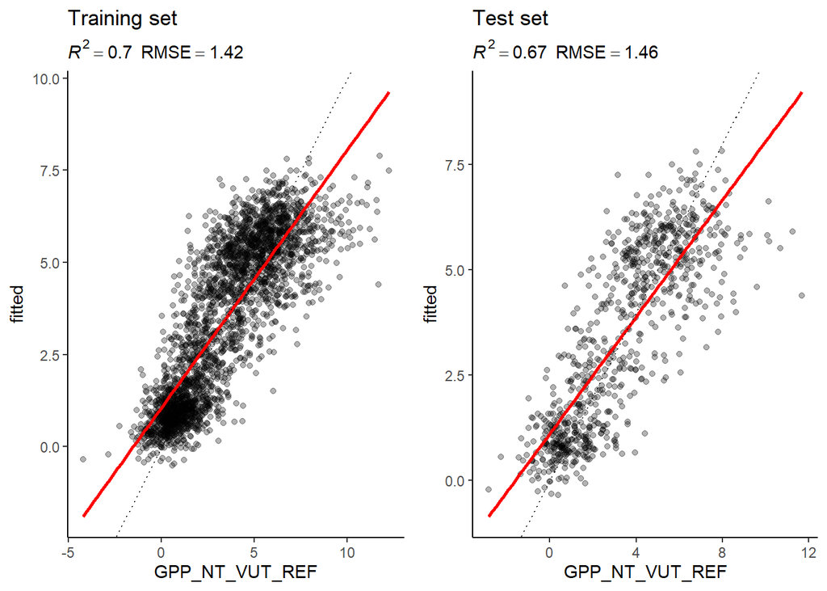

```r
# KNN
eval_model(mod = knn_model, df_train = daily_fluxes, df_test = daily_fluxes_test)
```

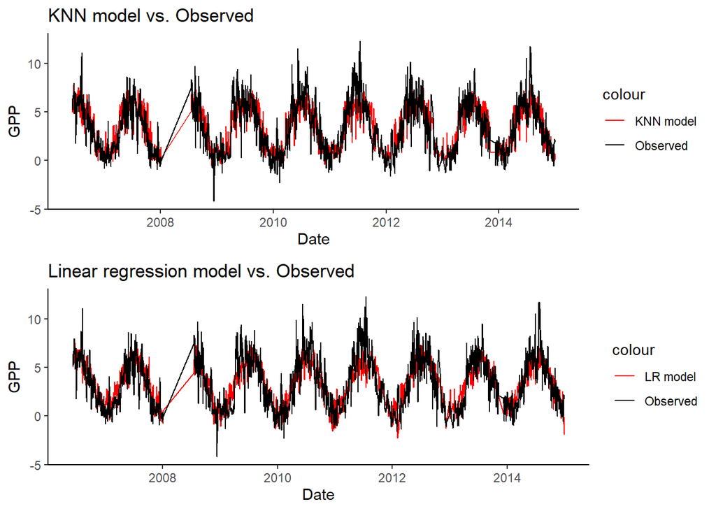

```r
# prepare the data
daily_fluxes_vis <- daily_fluxes |> drop_na()

# make predictions
daily_fluxes_vis$GPP_lm <- predict(lm_model, newdata = daily_fluxes_vis)
daily_fluxes_vis$GPP_knn <- predict(knn_model, newdata = daily_fluxes_vis)

plot_lm_obs <- ggplot(daily_fluxes_vis) +
  geom_line(aes(x = TIMESTAMP, y = GPP_knn, color = "KNN model")) +
  geom_line(aes(x = TIMESTAMP, y = GPP_NT_VUT_REF, color = "Observed")) +
  labs(
    title = "KNN model vs. Observed",
     x = "Date",
    y = "GPP"
  ) +
  theme_classic() +
  scale_color_manual(values = c("KNN model" = "red", "Observed" = "black"))

plot_knn_obs <- ggplot(daily_fluxes_vis) +
  geom_line(aes(x = TIMESTAMP, y = GPP_lm, color = "LR model")) +
  geom_line(aes(x = TIMESTAMP, y = GPP_NT_VUT_REF, color = "Observed")) +
  labs(
    title = "Linear regression model vs. Observed",
    x = "Date",
    y = "GPP"
  ) +
  theme_classic() +
  scale_color_manual(values = c("LR model" = "red", "Observed" = "black"))

plot_grid(plot_lm_obs, plot_knn_obs, nrow = 2)
```

This is quite neat, but it is easier to make a statement if you see all three combined.

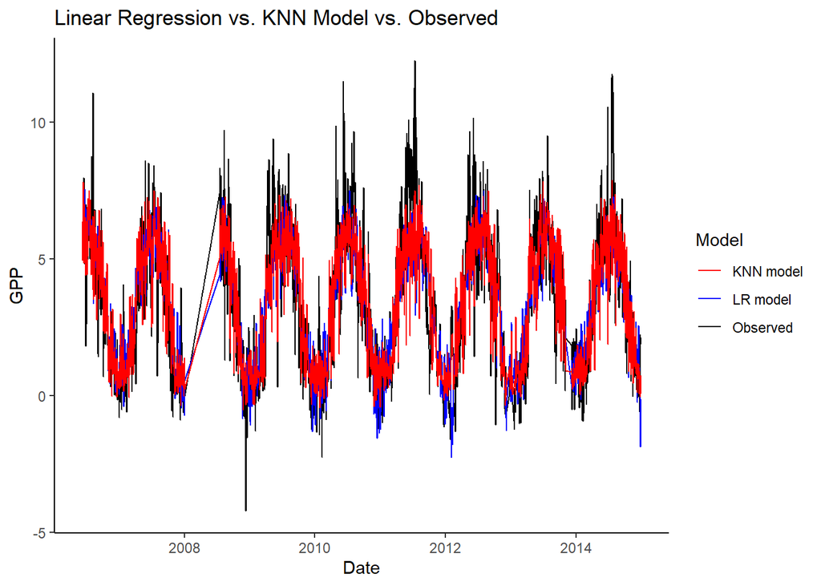

```r
plot_lm_knn_obs <- ggplot(daily_fluxes_vis, aes(x = TIMESTAMP)) +
  geom_line(aes(y = GPP_NT_VUT_REF, color = "Observed")) +
  geom_line(aes(y = GPP_lm, color = "LR model")) +
  geom_line(aes(y = GPP_knn, color = "KNN model")) +
  labs(
    title = "Linear Regression vs. KNN Model vs. Observed",
    x = "Date",
    y = "GPP",
    color = "Model"
  ) +
  theme_classic() +
  scale_color_manual(
    values = c(
      "Observed" = "black",
      "LR model" = "blue",
      "KNN model" = "red"
    )
  )

plot_lm_knn_obs
```

Here, it can be seen that the KNN model is more fitting, while the linear regression model has a bit more outliers. I must admit, I have a hard time understanding why the LR model has more outliers, although the model being underfitted. As far as I understand it, the KNN model should have more outliers because it is overfitted to the training data.

## 2 Comparison of KNN models with varying k

Now, in the second part of this report, my aim is to make a statement about the goodness of the KNN model depending on the k that is used in the model. My hypothesis is that with k approaching 1, the bias of the model will be very low, but the variance will be high, so the model is severely overfitted. Contrarily, with k approaching N (the number of observations in the data), the variance will decrease, but it will have a high bias, resulting in a severely underfitted model.

```r
# data frame for the results
k_results <- data.frame(
  k = numeric(),
  rsq_train = numeric(),
  mae_train = numeric(),
  rmse_train = numeric(),
  rsq_test = numeric(),
  mae_test = numeric(),
  rmse_test = numeric()
)


# iterate knn model with varying k
for (k_value in seq(1:60)) { # only until 60 because of the computation time - feel free to run it with higher k
  knn_model <- caret::train(
  pp,
  data = daily_fluxes_train |> drop_na(),
  method = "knn",
  trControl = caret::trainControl(method = "none"),
  tuneGrid = data.frame(k = k_value),
  metric = "RMSE"
  )

  #get metrics
  knn_metrics <- eval_metrics(knn_model, daily_fluxes_train, daily_fluxes_test)

  k_results <- bind_rows(k_results, data.frame(k = k_value, knn_metrics
  ))

}
```

Let’s plot the results.

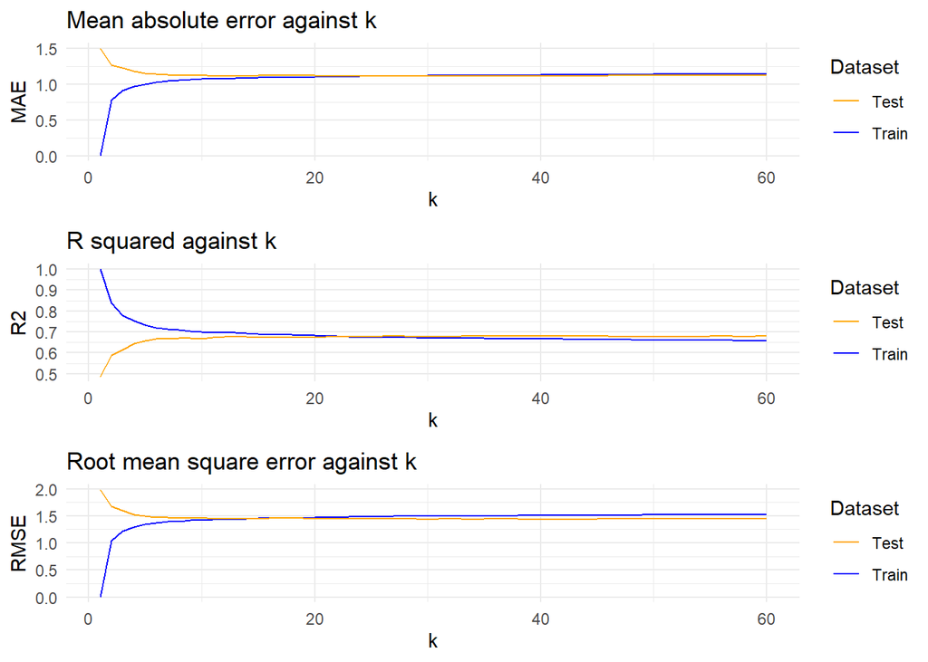

```r
# plot mae against k
plot_mae_k <- ggplot(k_results, aes(x = k)) +
  geom_line(aes(y = mae_train, color = "Train")) +
  geom_line(aes(y = mae_test, color = "Test")) +
  labs(
    title = "Mean absolute error against k",
    x = "k",
    y = "MAE",
    color = "Dataset") +
  theme_minimal() +
  scale_color_manual(values = c("Train" = "blue", "Test" = "orange"))


# plot rsq against k
plot_rsq_k <- ggplot(k_results, aes(x = k)) +
  geom_line(aes(y = rsq_train, color = "Train")) +
  geom_line(aes(y = rsq_test, color = "Test")) +
  labs(
    title = "R squared against k",
    x = "k",
    y = "R2",
    color = "Dataset") +
  theme_minimal() +
  scale_color_manual(values = c("Train" = "blue", "Test" = "orange"))


# plot rmse against k
plot_rmse_k <- ggplot(k_results, aes(x = k)) +
  geom_line(aes(y = rmse_train, color = "Train")) +
  geom_line(aes(y = rmse_test, color = "Test")) +
  labs(
    title = "Root mean square error against k",
    x = "k",
    y = "RMSE",
    color = "Dataset") +
  theme_minimal() +
  scale_color_manual(values = c("Train" = "blue", "Test" = "orange"))


plot_grid(plot_mae_k, plot_rsq_k, plot_rmse_k, nrow = 3)
```

Here’s the code that evaluates the exact best k.

```r
# find the optimal k
k_optimal <- which.min(k_results$mae_test)

k_optimal
```

```
## [1] 34
```